# 03 - Data Visualisation 2

31 August, 2018

## overview

## Lesson Structure

Thanks to last week's snow, we'll recap on some of the topics from last week.

We'll look at:

- Reading data into R from external sources
- Understanding the ggplot syntax
- Plotting discrete and continuous data
- Changing basic visual features of plots

## Getting Started

First, we'll load the packages necessary for this class.

```r
library(tidyverse)
```

## Loading Data

For this recap and the main part of the lessons, we'll use some simulated data of reaction times.

Load the .csv file from the inputs folder. `read_csv()` is a quick way to load data as a tibble.

```r
rt_data <- read_csv("inputs/rt_data.csv")
```

## Understanding the Data

Let's see what the data looks like:

```r
rt_data
```

```
## # A tibble: 60 x 4
##    particpant gender response_condition reaction_time
##         <int> <chr>  <chr>                      <dbl>
##  1          1 male   match                       340.
##  2          2 female match                       350.
##  3          3 male   match                       273.
##  4          4 female match                       299.
##  5          5 female match                       263.
##  6          6 male   match                       319.
##  7          7 female match                       307.
##  8          8 female match                       369.
##  9          9 male   match                       293.
## 10         10 male   match                       285.
## # ... with 50 more rows
```

## ggplot

## Basics of Plotting

Every `ggplot` call must have a data argument!

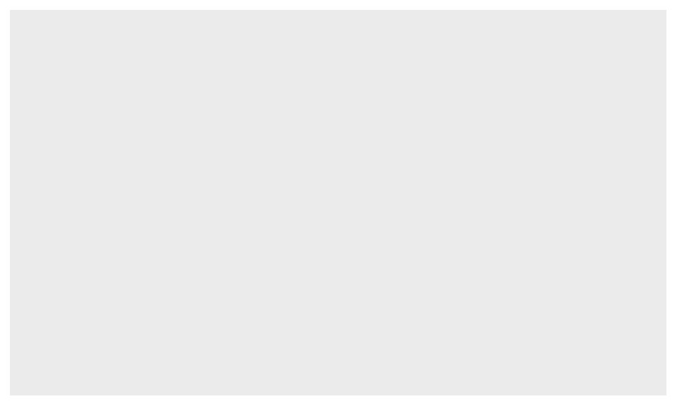

```r
ggplot(data = rt_data)
```

… but that's not interesting. We've just made a canvas for our data.

## Mapping your Data onto the Plot

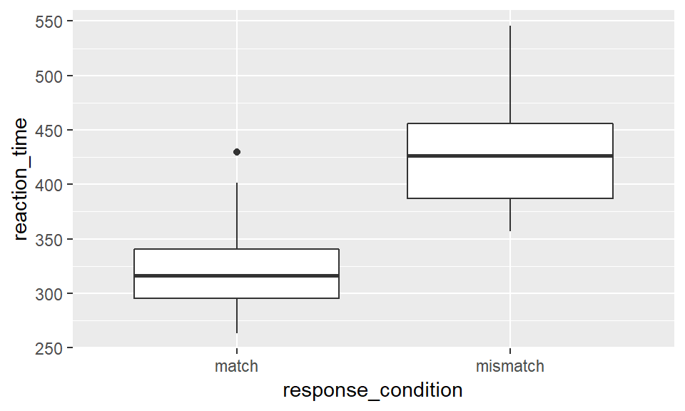

```r
ggplot(data = rt_data) +
  geom_boxplot(mapping = aes(x = response_condition,
                             y = reaction_time)
               )
```

This is the most basic boxplot you can make in ggplot.

## Customising our Plots

### Adding Colour across Variables

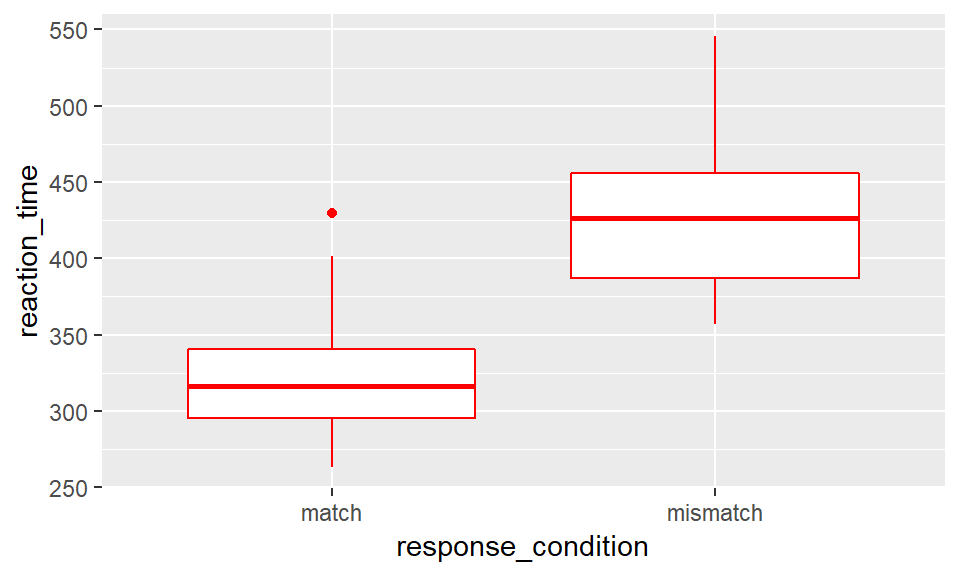

```r
ggplot(data = rt_data) +
  geom_boxplot(mapping = aes(x = response_condition,
                             y = reaction_time),
               colour = "red"
               )
```

## Customising our Plots

### Adding Colour by Variables

Notice, we get a legend when we add colours by variables.

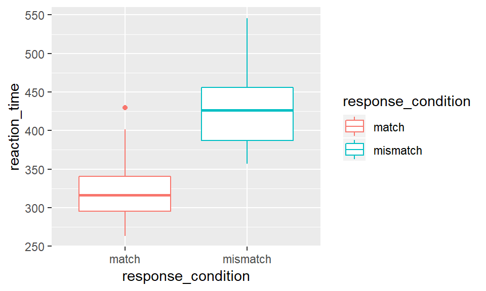

```r
ggplot(data = rt_data) +
  geom_boxplot(mapping = aes(x = response_condition,
                             y = reaction_time,
                             colour = response_condition))
```

## Customising our Plots

What if we want to expand our y-axis? Set your limits!

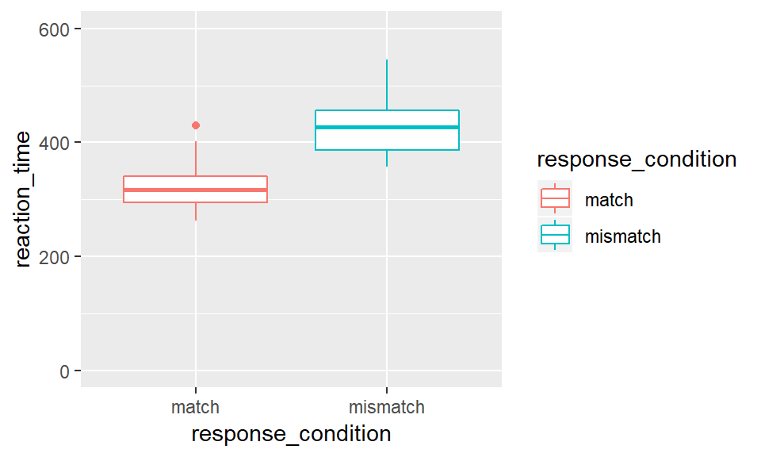

```r
ggplot(data = rt_data) +
  geom_boxplot(mapping = aes(x = response_condition,
                             y = reaction_time,
                             colour = response_condition)
               ) +
  coord_cartesian(ylim = c(0, 600))
```

## Density Plots

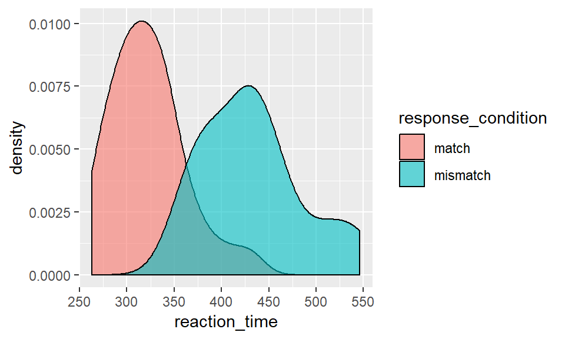

```r
ggplot(data = rt_data, aes(x = reaction_time)) +
  geom_density(mapping = aes(fill = response_condition),
               alpha = 0.6
               )
```

## Bar Plots

Good for showing counts: Here by gender and response condition.

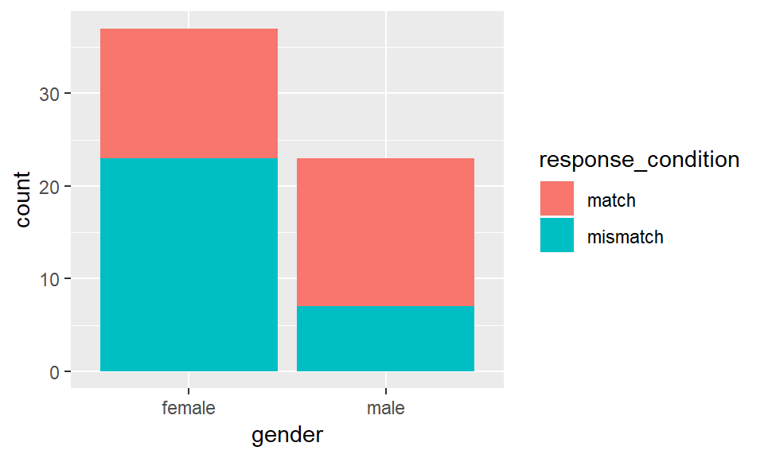

```r
ggplot(data = rt_data, aes(x = gender)) +
  geom_bar(mapping = aes(fill = response_condition))
```

… not so great for non-count data.

## Pirate Plots! Rrrrrrrrrrr

Great for the the indecisive. Shows:

- Bars of mean scores
- Box of 95% confidence interval around the mean
- Violins for density and distribution of scores
- Raw data points

Let's load it!

```r
# install.packages("devtools")
# devtools::install_github("mikabr/ggpirate")
library(ggpirate)
```

## Pirate Plots! Rrrrrrrrrrr

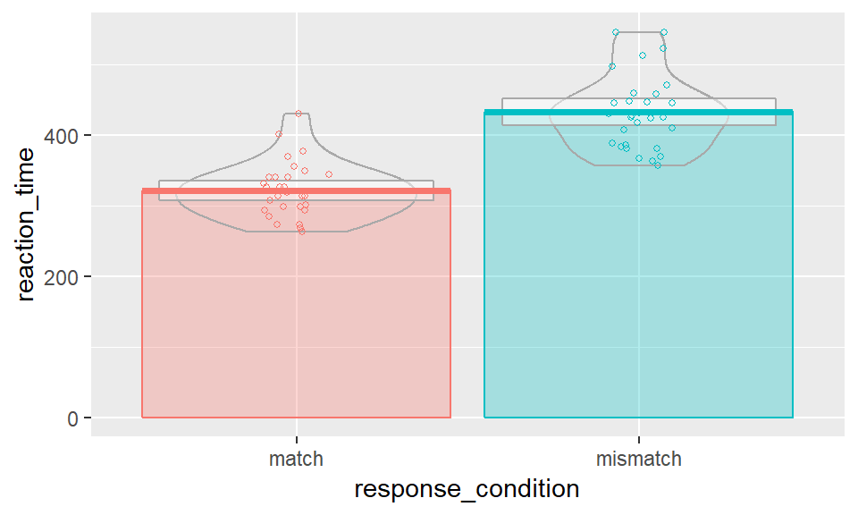

```r
ggplot(data = rt_data,
       mapping = aes(x = response_condition,
                     y = reaction_time,
                     fill = response_condition,
                    colour = response_condition)
       ) +
  geom_pirate()
```

## Saving Plots as Objects

- Avoid retyping/rerunning the same code: Assign to an object!

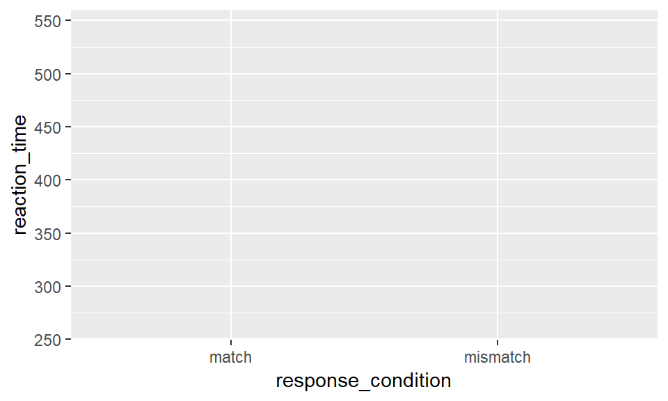

```r
pirate_plot <- ggplot(data = rt_data,
                      mapping = aes(x = response_condition,
                                    y = reaction_time,
                                    fill = response_condition,
                                    colour = response_condition)
                      )
pirate_plot # enter name in console to see the plot!
```

## Saving Plots as Objects

This looks neater now…

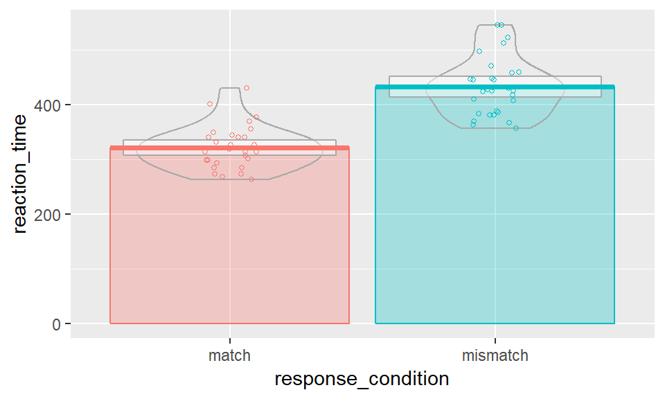

```r
pirate_plot + geom_pirate()
```

## Extreme Customisation!

```r
pirate_plot +
  geom_pirate() +
  labs(x = "Response Condition", y = "Reaction Time (ms)") +
  scale_x_discrete(labels = c("Match", "Mismatch")) +
  theme_classic() +
  scale_fill_manual(values = c("red", "blue")) +
  scale_colour_manual(values = c("red", "blue")) +
  geom_hline(yintercept = 480, linetype = 2) +
  annotate(geom = "text", x = 1, y = 500,
           label = "Very Slow Performance")
```

## Extreme Customisation!

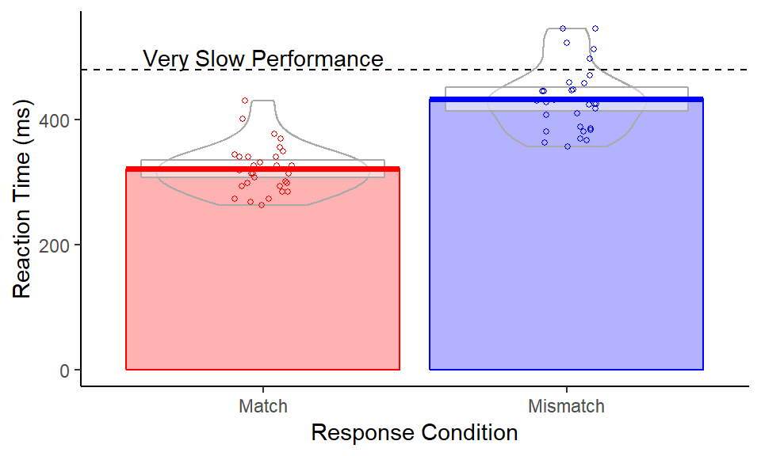

Why no legend? ggpirate defaults to remove that (not necessary for discrete data).

## Faceting

## Faceting

- A useful way to make multiple plots on one canvas
- Useful for splitting categories in your data

For splitting by one category:

```r
facet_wrap(~ category)
```

For multiple categories:

```r
facet_grid(category_one ~ category_two)
```

Both cases can take two categories, but the grid layout is more interpretable for multiple categories.

## Facet Examples

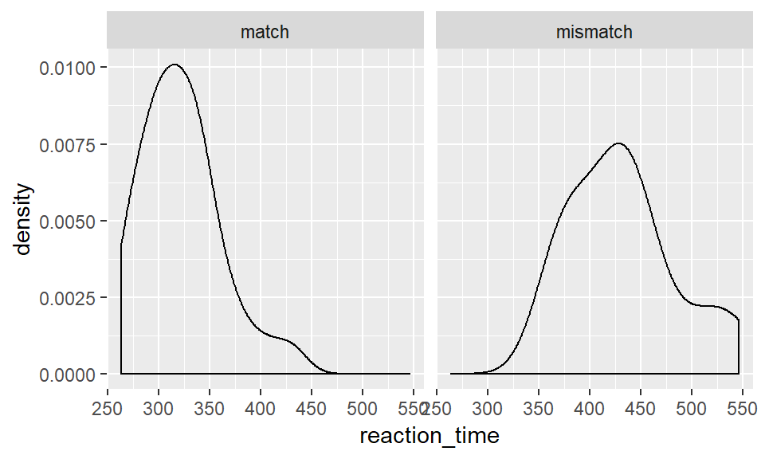

```r
ggplot(data = rt_data,
       mapping = aes(x = reaction_time)
       ) +
  geom_density() +
  facet_wrap(~ response_condition)
```

## Facet Examples

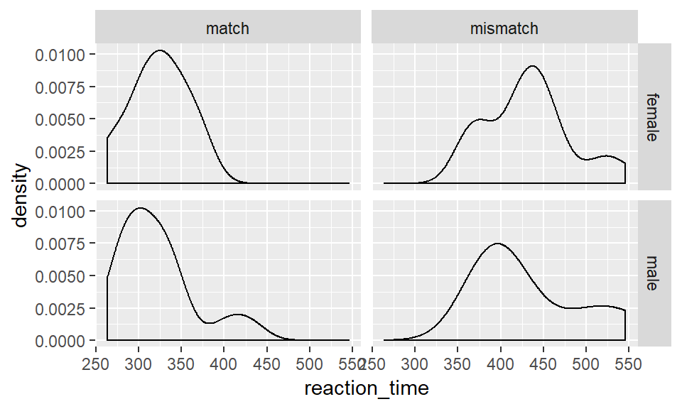

```r
ggplot(data = rt_data,
       mapping = aes(x = reaction_time)
       ) +
  geom_density() +
  facet_grid(gender ~ response_condition)
```

## Calculating Statistics

## Means and SE

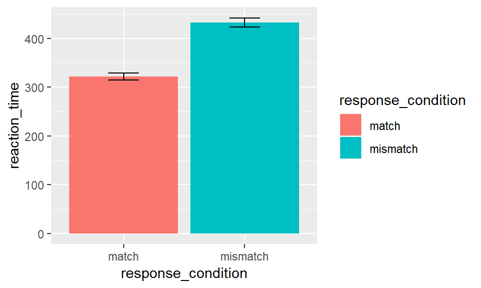

```r
ggplot(data = rt_data,
       mapping = aes(
         x = response_condition,
         y = reaction_time,
         fill = response_condition)
       ) +
  stat_summary(fun.y = mean, geom = "bar") +
  stat_summary(fun.data = "mean_se", geom = "errorbar", width = 0.25)
```

## Model Fits

Defaults to loess smooth.

```r
# filter extreme values
starwars <- filter(starwars, mass < 160)

# plot
ggplot(data = starwars,
       mapping = aes(x = mass, y = height)
       ) +
  geom_point() +
  geom_smooth()
```

## Model Fits

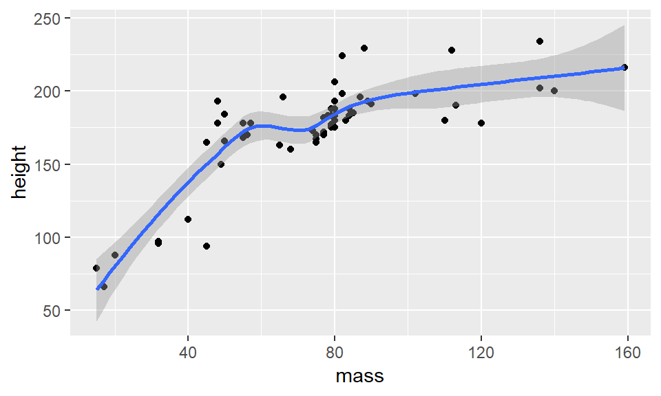

## Model Fits

Fitting a linear model

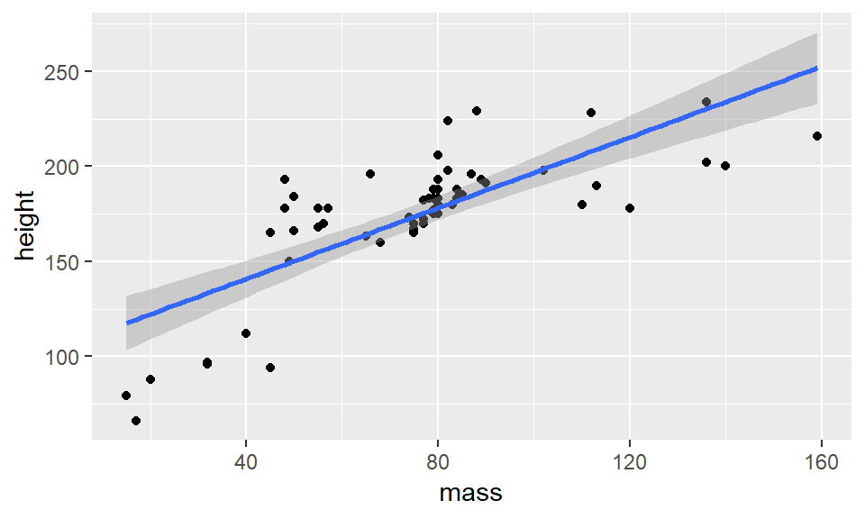

```r
ggplot(data = starwars,
       mapping = aes(x = mass, y = height)
       ) +
  geom_point() +
  geom_smooth(method = "lm", formula = "y ~ x")
```

## Combining Plots

## Combining Plots

```r
linear_plot <-
  ggplot(data = starwars,
       mapping = aes(x = mass, y = height)
       ) +
  geom_point() +
  geom_smooth(method = "lm", formula = y ~ x)
```

```r
quadratic_plot <-
  ggplot(data = starwars,
       mapping = aes(x = mass, y = height)
       ) +
  geom_point() +
  geom_smooth(method = "lm", formula = y ~ poly(x, 2))
```

*Note*: We can save on retyping everything above geom smooth by saving the arguments to a basic `plot`, then adding that + `geom_smooth()` to our quadratic/linear plot names.

## Combining Plots

```r
library(cowplot)
combined_plots <- plot_grid(linear_plot,
                            quadratic_plot,
                            labels = c("A", "B"), # label plots
                            align = "h" # align axes
                            )
```

## Combining Plots

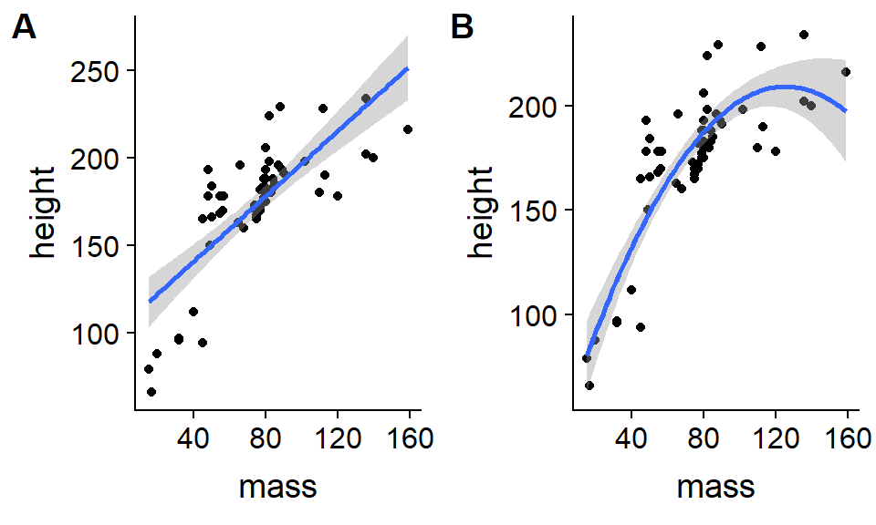

```r
combined_plots
```

## Saving

## Saving

Define the location and name of the file in the `filename` argument.

Define the object to save in your plot argument.

*Note*: Here, we use **relative** file paths. We tell R, in the current folder, find the outputs folder, within that (/) save the image as a .png by the name starwars_mass_by_height.

```r
ggsave(filename = "outputs/starwars_mass_by_height.png",
       plot = combined_plots
       )
```